#### Abstract:

In this report I am going to fit a linear and multiple regression model on the dataset human. I will use the model to make predictions and check the models for their validity. Furthermore I will conduct linear discriminant analysis (LDA) with the data, train the LDA-model and make predictions that I can verify or prove wrong with a test dataset. The report has the purpose to introduce the statistical methods and to explore the options that r provides to express data and the outcome of the data assessment graphically.

# 1. The dataset “human”

The dataset originates from the [United Nationa Development Programme (UNDP)](http://hdr.undp.org/en/content/human-development-index-hdi). The UNDP aims to compare the development of countries and regions of the world, including not only growth alone, but many different variables. In this exercise we are using a subset, that I created from the original data. I selected certain variables concerning health and education as well as the Human Development Index (HDI) and the Gross National Income per capita (GNI). Missing values were removed from the dataset. The file of the data wrangling can be found [here](https://github.com/evaroth/IODS-final/blob/master/datawrangling.R).

The dataset contains 155 observations of 8 variables. The observations are made for 155 countries. Out of the 8 variables GNI and Mat.Mor are integer variables, the others are numerical. In the following list you may see the names of the variables and what kind of information they have recorded.

- **HDI:** human development index
- **Edu2.FM:** ratio of women with at least secondary education to men with at least seconday reducation
- **Life.Exp:** life expectancy at birth
- **Mean.Edu:** mean years of education
- **GNI:** gross national income per capita
- **Mat.Mor:** maternal mortality ratio
- **Ado.Birth:** adolescent birth rate
- **Parli.F:** percentage of female representatives in parliament

I hypothesize, that the variables concerning education (Edu.FM, Mean.Edu, Parli.F) have a strong influence on the variables concerning health (Life.Exp, Mat.Mor, Parli.F). A better education equally for men and women, has eventually a better influence on life expectancy and health condition of a people.

```r
#At first I am accessing all the packages that I will be using during this exercise
library(GGally)
library(ggplot2)
library(MASS)
library(corrplot)
#Now we read the data
human <- read.csv("/Users/eva-mariaroth/Documents/GitHub/IODS-final/human_.csv", header = TRUE, sep= ",")
#Exploring the data, its structur and dimensions
str(human)
```

```
## 'data.frame':    155 obs. of  8 variables:
##  $ HDI      : num  0.944 0.935 0.93 0.923 0.922 0.916 0.916 0.915 0.913 0.913 ...
##  $ Edu2.FM  : num  1.007 0.997 0.983 0.989 0.969 ...
##  $ Life.Exp : num  81.6 82.4 83 80.2 81.6 80.9 80.9 79.1 82 81.8 ...
##  $ Mean.Edu : num  12.6 13 12.8 12.7 11.9 13.1 12.2 12.9 13 12.5 ...
##  $ GNI      : int  64992 42261 56431 44025 45435 43919 39568 52947 42155 32689 ...
##  $ Mat.Mor  : int  4 6 6 5 6 7 9 28 11 8 ...
##  $ Ado.Birth: num  7.8 12.1 1.9 5.1 6.2 3.8 8.2 31 14.5 25.3 ...
##  $ Parli.F  : num  39.6 30.5 28.5 38 36.9 36.9 19.9 19.4 28.2 31.4 ...
```

```r
summary(human)
```

```
##       HDI            Edu2.FM          Life.Exp        Mean.Edu
##  Min.   :0.3480   Min.   :0.1717   Min.   :49.00   Min.   : 1.400
##  1st Qu.:0.5925   1st Qu.:0.7264   1st Qu.:66.30   1st Qu.: 6.000
##  Median :0.7330   Median :0.9375   Median :74.20   Median : 8.500
##  Mean   :0.7039   Mean   :0.8529   Mean   :71.65   Mean   : 8.302
##  3rd Qu.:0.8290   3rd Qu.:0.9968   3rd Qu.:77.25   3rd Qu.:10.900
##  Max.   :0.9440   Max.   :1.4967   Max.   :83.50   Max.   :13.100
##       GNI            Mat.Mor         Ado.Birth         Parli.F
##  Min.   :   581   Min.   :   1.0   Min.   :  0.60   Min.   : 0.00
##  1st Qu.:  4198   1st Qu.:  11.5   1st Qu.: 12.65   1st Qu.:12.40
##  Median : 12040   Median :  49.0   Median : 33.60   Median :19.30
##  Mean   : 17628   Mean   : 149.1   Mean   : 47.16   Mean   :20.91
##  3rd Qu.: 24512   3rd Qu.: 190.0   3rd Qu.: 71.95   3rd Qu.:27.95
##  Max.   :123124   Max.   :1100.0   Max.   :204.80   Max.   :57.50
```

I want to take a closer look at the variables and their relationships to each other. In order to do this I can pair the variables and see if there are correlations.The plot matrix in figure 1 shows us the distribution of the data for each variable. The variables are paired and the results are shown graphically in scatter plots and with the Correlation Coefficient. We can find the highest correlation between Life Expectancy and HDI with a correlation coefficient of 0.905.

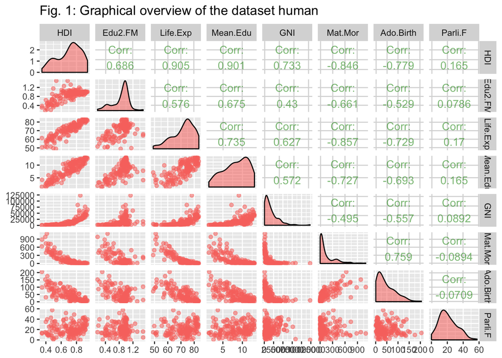

```r
p <- ggpairs(human, mapping = aes(col = "green4", alpha = 0.9), lower = list(combo = wrap("facethist", bins = 18)), title = "Fig. 1: Graphical overview of the dataset human")
p
```

Another way to get a quick overview about the correlation of the variables is the correlation plot. In the correlation plot the colour indicates what kind of correlation we have:  
red - negative correlation  
blue - positive correlation  
The size of the cirlce and the intensity of the colour indicate the correlation coefficient.  
strong colours - corrolation coefficient is high  
light colours - corrolation coefficient is low

In figure 2 can see that the the variables are strongly correlating with each other, except for the amount of female representatives in the parliament. It does not seem to have a significant influence on HDI, GNI or Life Expectancy. Obviously other factors play a bigger role here. There are strong positive correlations between HDI, Life Expectancy and Mean Education. Strong negative correlations can be found between HDI and Maternal mortality ratio as well as life expectancy and maternal mortality ratio.

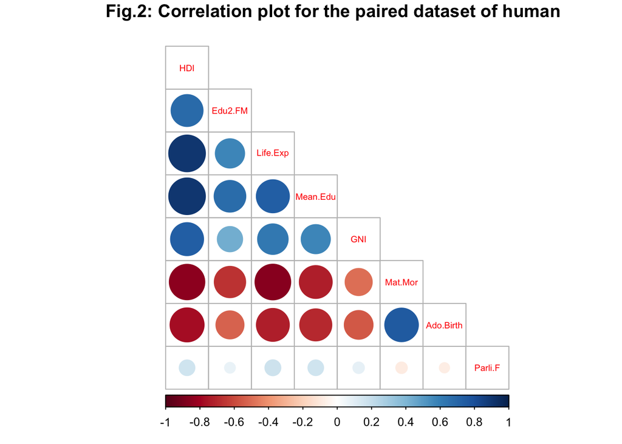

```r
cor_matrix<-cor(human)
corrplot(cor_matrix, method="circle", type = "lower", cl.pos = "b", tl.pos = "d", tl.cex = 0.6, title = "
         Fig.2: Correlation plot for the paired dataset of human")
```

# 2. Regression analysis

## 2.1 Simple linear regression model

In order to find out more about the impact of education on health we will perform a regression analysis for the varibales Mean.Edu and Life.Exp, the two variables, very simplified, standing for education and health. In figure 3 we can see the observations of theses variables plotted against each other and a linear regression line fitted to them.

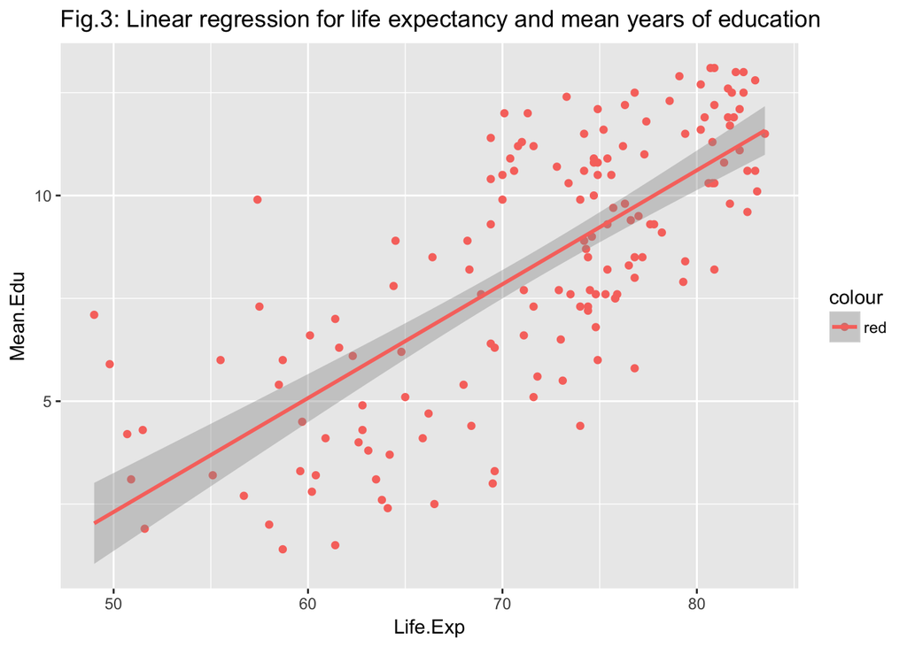

```r
#creating a scatter plot of Life.Exp versus Mean.Edu with a linear regression line
qplot(Life.Exp, Mean.Edu, data = human, main = "Fig.3: Linear regression for life expectancy and mean years of education", colour = "red") + geom_smooth(method = "lm")
```

Life.Exp is the dependant variable y and Mean.Edu the explanatory variable x. Alpha indicates the point where the regression line intercepts the y-axis and beta to the slope of the regression line. Epsilon is an unobservable random variable, that is assumed to add noise to the observations and describes the errors of the model. The summary of the simple regression model at first shows us the formula applied, indicating the dependant variable and the explanatory variable. Then it gives us a summary of the residuals of the model. The residuals describe the prediction errors, i.e. the difference between the predicitions and the actual values. The estimate of the intercept describes the alpha parameter. In this case it would be 55.46. The estimate for the variable Mean.Edu gives us the beta parameter: 1,95. The P value of the model is very small, that means that the correlation between the variables is highly significant.

```r
#fitting a linear model where Life.Exp is the target, whereas mean. edu is the explanatory variable
my_model <- lm(Life.Exp ~ Mean.Edu, data = human)
summary(my_model)
```

```
##
## Call:
## lm(formula = Life.Exp ~ Mean.Edu, data = human)
##
## Residuals:
##     Min      1Q  Median      3Q     Max
## -20.310  -3.097   1.455   4.250  10.025
##
## Coefficients:
##             Estimate Std. Error t value Pr(>|t|)
## (Intercept)  55.4648     1.2913   42.95   <2e-16 ***
## Mean.Edu      1.9500     0.1455   13.40   <2e-16 ***
## ---
## Signif. codes:  0 '***' 0.001 '**' 0.01 '*' 0.05 '.' 0.1 ' ' 1
##
## Residual standard error: 5.67 on 153 degrees of freedom
## Multiple R-squared:  0.5398, Adjusted R-squared:  0.5368
## F-statistic: 179.5 on 1 and 153 DF,  p-value: < 2.2e-16
```

## 2.2 Making predictions using the simple regression model

Using the model, that I wrote, we can make predictions, about the life expectancy that we would find in countries, if the mean years of education would change. For this purpose I have added examplarily new values for the mean years of education for six countries. In table 2 we can see the predicted life expectancy that these countries would have, if the mean years of education would correspond to the newly entered values.

Tab. 1: Predicted for the six countries after adding new data

```r
#predicting
m <- lm(Life.Exp ~ Mean.Edu, data = human)

# New observations
new_mean.edu <- c("Niger" = 12.1, "Chad"= 11.5, "Mali" = 10.3, "Nepal" = 10.5, "Haiti" =11.7, "Yemen" = 10)
new_data <- data.frame(Mean.Edu = new_mean.edu)

# Print out the predicted values
predict(m, newdata = new_data)
```

```
##    Niger     Chad     Mali    Nepal    Haiti    Yemen
## 79.05974 77.88975 75.54976 75.93976 78.27975 74.96476
```

Tab.2:Mean years of education and life expectancy, and the predicted life expectancy if the number of mean years of education would be substantially higher, calculated with the model for six countries.

| Country | Mean.Edu | Life.Exp | Mean.Edu new | Life.exp predicted |
| --- | --- | --- | --- | --- |
| Niger | 1.5 | 61.4 | 12.1 | 79.1 |
| Chad | 1.9 | 51.6 | 11.5 | 77.9 |
| Mali | 2.0 | 58.0 | 10.3 | 75.6 |
| Nepal | 3.3 | 69.6 | 10.5 | 75.9 |
| Haiti | 4.9 | 62.8 | 11.7 | 78.3 |
| Yemen | 2.6 | 63.8 | 10.0 | 74.9 |

## 2.3 Multiple linear regression model

```r
#fitting a multiple regression model with several explanatory variables
my_model2 <- lm(Life.Exp ~ Mean.Edu + Edu2.FM + Parli.F, data =human)
summary(my_model2)
```

```
##
## Call:
## lm(formula = Life.Exp ~ Mean.Edu + Edu2.FM + Parli.F, data = human)
##
## Residuals:
##      Min       1Q   Median       3Q      Max
## -20.3605  -2.9382   0.8658   4.1325  10.0736
##
## Coefficients:
##             Estimate Std. Error t value Pr(>|t|)
## (Intercept) 52.63771    1.80212  29.209  < 2e-16 ***
## Mean.Edu     1.65585    0.19758   8.381  3.4e-14 ***
## Edu2.FM      5.19954    2.53954   2.047   0.0423 *
## Parli.F      0.03991    0.03998   0.998   0.3198
## ---
## Signif. codes:  0 '***' 0.001 '**' 0.01 '*' 0.05 '.' 0.1 ' ' 1
##
## Residual standard error: 5.615 on 151 degrees of freedom
## Multiple R-squared:  0.5546, Adjusted R-squared:  0.5458
## F-statistic: 62.68 on 3 and 151 DF,  p-value: < 2.2e-16
```

In the summary of the model we can see, that on the mean years of education have a highly significant correlation with life expectancy. There is no significant correlation between female members in parliament and life expectance.

## 2.4 Validity check for both models

Linear regression models assume that the errors are normally distributed, not correlated and have constant variance, i.e. the size of the error does not depend on the explanatory variables. By analysing the residuals of the model we can explore the validity of the model assumptions.

Below we can see the three diagnostic plots “Residuals versus Fitted”, “Normal QQ” and “Residuals vs Leverage” for the simple linear regression .

The scatter plot of residuals versus fitted proves or disproves the assumption of the constant variance assumption. There is a small tendency of the spread of the residuals to decrease with increasing fitted values. However, the tendancy is not clear. Therefore, i conclude, that the constant variance assumtpion applies.

The QQ plot shows the distribution of the errors. The better the values fit to the dotted line, the more are they normally distributed. We can see that the values fit reasonably well, which means that they are evenly distributed. However, the model seems to be less suitable in both ends of the values. Then there is a small deviation between the line and the errors.

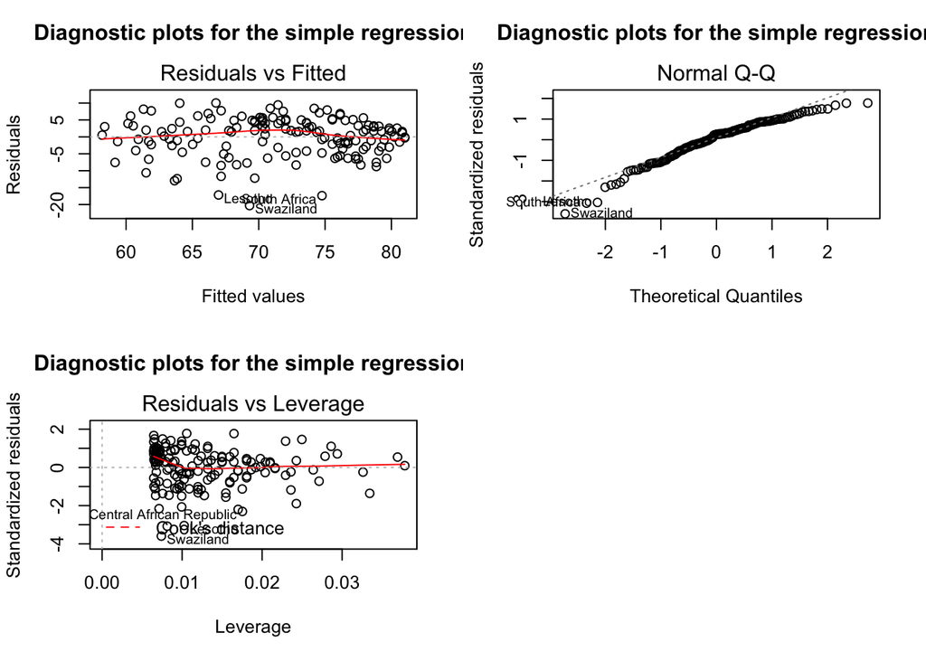

```r
par(mfrow = c(2,2))
plot(my_model, which = c(1,2,5), main = "Diagnostic plots for the simple regression
")
```

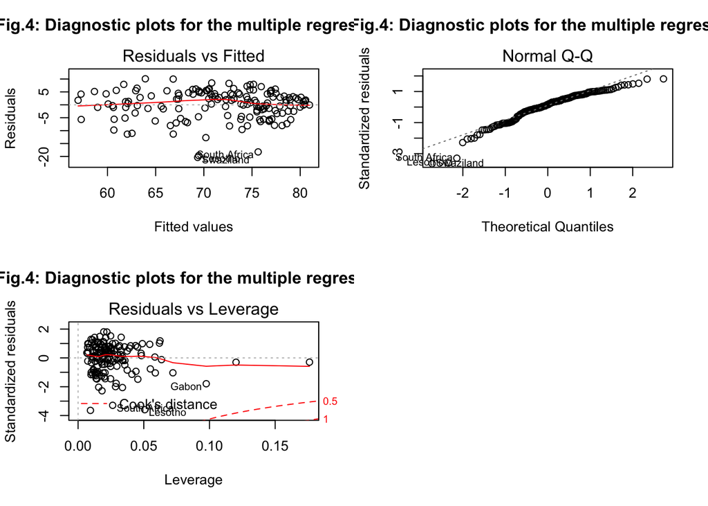

```r
#exploring validity of the model by drawing diagnostic plots
par(mfrow = c(2,2))
plot(my_model2, which = c(1,2,5), main= "Fig.4: Diagnostic plots for the multiple regression
     ")
```

# 3. Performing Linear Discriminant analysis

## 3.1 Preparing the dataset

Liner Discriminant Analysis is a classification method that can be used to model binary or multiple class variables. The target variable has to be categorical. Furthermore it is a variable reduction technique. The dependant variables is explained by dimensions instead of variables. The dimensions combine the different variables. In order to conduct the linear discriminant analysis the dataset needs to be adjusted. I am dropping the HDI and GNI variables from the set as they are not interesting for our research question. Then I am scaling the standard set, using the function scale(), as the data contains only numerical values. The scaling needs to be done, because the linear discriminant analysis assumes that the variables are normally distributed and the variance of each variable is the same. In the scaling process the column means are substracted from the corresponding columns and divided by the standard deviatin. After scaling all the observations are between integral 10 and have a mean of 0.0. Now they can be related to each other and the disctances between the groups can be calculated.

```r
#keep only the columns regarding health and education
human2 <- read.csv("/Users/eva-mariaroth/Documents/GitHub/IODS-final/human2.csv", header = TRUE, sep= ",")
human_scaled <- scale(human2)
# summaries of the scaled variables
summary(human_scaled)
```

```
##     Edu2.FM           Life.Exp          Mean.Edu           Mat.Mor
##  Min.   :-2.8189   Min.   :-2.7188   Min.   :-2.19845   Min.   :-0.6992
##  1st Qu.:-0.5233   1st Qu.:-0.6425   1st Qu.:-0.73323   1st Qu.:-0.6496
##  Median : 0.3503   Median : 0.3056   Median : 0.06309   Median :-0.4726
##  Mean   : 0.0000   Mean   : 0.0000   Mean   : 0.00000   Mean   : 0.0000
##  3rd Qu.: 0.5958   3rd Qu.: 0.6717   3rd Qu.: 0.82755   3rd Qu.: 0.1932
##  Max.   : 2.6646   Max.   : 1.4218   Max.   : 1.52831   Max.   : 4.4899
##    Ado.Birth          Parli.F
##  Min.   :-1.1325   Min.   :-1.8203
##  1st Qu.:-0.8394   1st Qu.:-0.7409
##  Median :-0.3298   Median :-0.1403
##  Mean   : 0.0000   Mean   : 0.0000
##  3rd Qu.: 0.6030   3rd Qu.: 0.6127
##  Max.   : 3.8344   Max.   : 3.1850
```

```r
# class of the human_scaled object
class(human_scaled)
```

```
## [1] "matrix"
```

```r
# change the object to data frame
human_scaled <- as.data.frame(human_scaled)
bins <- quantile(human_scaled$Life.Exp)
bins
```

```
##         0%        25%        50%        75%       100%
## -2.7188401 -0.6425237  0.3056208  0.6716765  1.4217908
```

Tab. 3: Number of observations in the four categories of variable Lifeexp

```r
#create a categorical variable Lifeexp
Lifeexp <- cut(human_scaled$Life.Exp, breaks = bins, include.lowest = TRUE, labels = c("low", "med_low", "med_high", "high"))
table(Lifeexp)
```

```
## Lifeexp
##      low  med_low med_high     high
##       39       41       36       39
```

```r
#remove original Life.Exp variable from the dataset
human_scaled <- dplyr::select(human_scaled, -Life.Exp)
#add the new categorical value to scaled data
human_scaled <- data.frame(human_scaled, Lifeexp)
str(human_scaled)
```

```
## 'data.frame':    155 obs. of  6 variables:
##  $ Edu2.FM  : num  0.639 0.596 0.54 0.562 0.481 ...
##  $ Mean.Edu : num  1.37 1.5 1.43 1.4 1.15 ...
##  $ Mat.Mor  : num  -0.685 -0.676 -0.676 -0.68 -0.676 ...
##  $ Ado.Birth: num  -0.957 -0.853 -1.101 -1.023 -0.996 ...
##  $ Parli.F  : num  1.627 0.835 0.661 1.488 1.392 ...
##  $ Lifeexp  : Factor w/ 4 levels "low","med_low",..: 4 4 4 4 4 4 4 4 4 4 ...
```

I will also try to make predictions with the LDA model. To prove the validity of the model, I can split my data into as train (80% of observations) and a test set (20% of observations). The model will be trained with the train set and verified with the test set as a control. Therefore, I am splitting the dataset.

```r
n<- nrow(human_scaled)
#choose randomly 80% of the rows
ind <-sample(n, size = n*0.8)
#create train set
train <- human_scaled[ind,]
#create test set
test <- human_scaled[-ind,]
# save the correct classes from the test data
correct_classes <- test$Lifeexp
#remove the Lifeexp variable from the test data
test <- dplyr::select(test, -Lifeexp)
```

Tab.4 & 5: Number of observations and variables for the train and the test set.

```r
# checking dimensions and observations of the two sets
dim(train)
```

```
## [1] 124   6
```

```r
dim(test)
```

```
## [1] 31  5
```

The train set has 124 observations of 6 variables and the test set 31 observations of 5 varibales. The missing variables is the Lifeexp. I excluded it, as we are going to predict this variables for the test set.

## 3.2 Fitting the LDA model

```r
lda.fit <- lda(Lifeexp ~ ., data  = train)
#printing the lda.fit object
lda.fit
```

```
## Call:
## lda(Lifeexp ~ ., data = train)
##
## Prior probabilities of groups:
##       low   med_low  med_high      high
## 0.2338710 0.2741935 0.2338710 0.2580645
##
## Group means:
##             Edu2.FM   Mean.Edu    Mat.Mor   Ado.Birth     Parli.F
## low      -1.1521249 -1.2000348  1.4061724  0.97093556 -0.08295729
## med_low   0.2931774  0.1108679 -0.2875845 -0.01058522 -0.19251931
## med_high  0.3558552  0.2575001 -0.5111502 -0.34162529 -0.05594199
## high      0.5009072  0.9101711 -0.6357554 -0.76534638  0.52101275
##
## Coefficients of linear discriminants:
##                   LD1        LD2        LD3
## Edu2.FM   -0.12395256  0.5287536  0.4256472
## Mean.Edu  -0.76945279 -0.8626384  1.1226979
## Mat.Mor    1.04844806 -1.0837413  0.5396920
## Ado.Birth  0.07721080  0.7995020  1.0690253
## Parli.F   -0.02211295 -0.5372821 -0.1228916
##
## Proportion of trace:
##    LD1    LD2    LD3
## 0.9087 0.0868 0.0045
```

We can draw a LDA biplot to visualize how the data is distributed. The biplot shows the two dimensions LD1 and LD2. Each colour represents a different category of Lifeexp and the pink arrows represent the predictor variables. Length and direction are based on the coefficients and show their impact on the model.

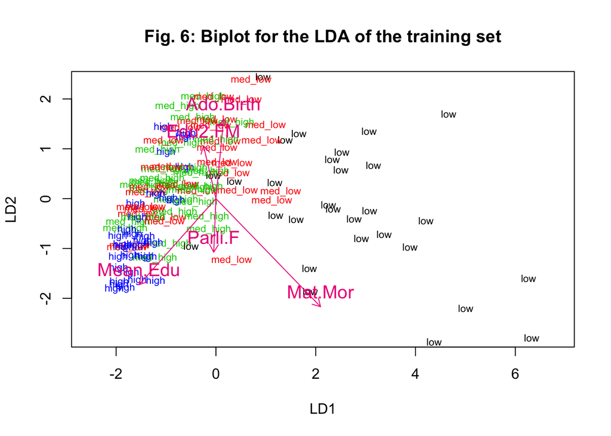

```r
#lda biplot arrows
lda.arrows <- function(x, myscale = 1, arrow_heads = 0.1, color = "deeppink2", tex = 1.25, choices = c(1,2)){
  heads <- coef(x)
  arrows(x0 = 0, y0 = 0,
         x1 = myscale * heads[,choices[1]],
         y1 = myscale * heads[,choices[2]], col=color, length = arrow_heads)
  text(myscale * heads[,choices], labels = row.names(heads),
       cex = tex, col=color, pos=3)
}
# target classes as numeric
classes <- as.numeric(train$Lifeexp)

# plot the lda results
plot(lda.fit, dimen = 2, col = classes, pch = classes, main = "Fig. 6: Biplot for the LDA of the training set")
lda.arrows(lda.fit, myscale = 2)
```

## 3.3 Making predictions with the LDA model

Tab. 6: Predicted observations and actual observations for the variable lifeexpectancy of the test set crosstabulated

```r
# predict classes with test data
lda.pred <- predict(lda.fit, newdata = test)

# cross tabulate the results
table(correct = correct_classes, predicted = lda.pred$class)
```

```
##           predicted
## correct    low med_low med_high high
##   low        9       1        0    0
##   med_low    2       4        1    0
##   med_high   0       3        3    1
##   high       0       0        0    7
```

# 4. Conclusion

From the statistical methods that I applied exemplarily, I can conclude that

- Education has a significant positive correlation with health, especially life expectancy.
- From the variables assessed, concerning education, mean years of education have the strongest influence on the life expectancy.
- If I wanted to establish a model to make predictions about Life expectancy, I should include more variables to have a more precise output.

# 5. Sources

All the information used can be found on the [MOOC](https://mooc.helsinki.fi/course/view.php?id=92) platform of the IODS-course.